# Intro

### Chart 1

**Trainer specifications:**  
To train the MELODY curriculum (a) trainer(s) should be selected. Good training skills is key in transferring knowledge. As this curriculum is taught to first responders, it is key to have a confident and hands-on trainer delivering the training.  
Minimum qualifications:  
- Experience in training. This can be either by having a formal training qualification and role, or experience in working with and supporting or mentoring junior staff  
- Background in C, B and/or RN  
- Professionally connected to the first responder services  
Plus relevant experience:  
- Experienced in working in an emergency setting either as a first responder or a hospital emergency department or  
- Experienced in collaborating with first responders or a hospital emergency department

### Image

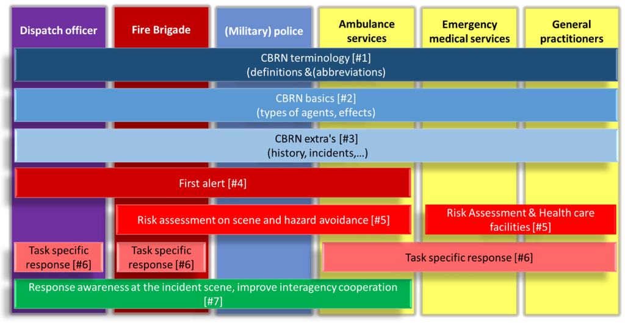

Schematic representation of the MELODY training structure

### Pane 3

**Acknowledgements** The material for this curriculum was developed and reviewed by the MELODY consortium, existing of RIVM, TNO, SCK-CEN, University of Rome Tor Vergata, University of Lodz, ECBRNE, ISEMI and evaluated by organising test events at HNP-BDU, ESRC-WFi, CBRN training centre Vught and Campus Vesta.

# Module 1+2

### Chart 1

**Contents**: What is CBRN (definitions; accidents v. attacks; C v. B v. RN).  
**Learning objectives**: To recognize CBRN terminology (to be able to speak a common language)  
This module explains what CBRN is. It contains definitions, the difference between accidents and attacks, and what the letters of CBRN stand for. The aim of this module is for all first responders to use the same terminology for effective communication.

### Chart 2

[figure not shown]

Dispatch center

### Overview Training Material

- Powerpoint slides

# Module 3

### Chart 2

### Pane 3

# Module 4

### Chart 2

### Pane 3

# Module 6

### Chart 2

### Pane 3

# Module 7

### Chart 2

### Pane 3

# Module 1+2

### Chart 2

### Pane 3

# Module 3

### Chart 2

### Pane 3

# Module 4

### Chart 2

### Pane 3

# Module 5

### Chart 2

### Pane 3

# Module 6

### Chart 2

### Pane 3

# Module 7

### Chart 2

### Pane 3

# Module 1+2

### Chart 2

### Pane 3

# Module 3

### Chart 2

### Pane 3

# Module 4

### Chart 2

### Pane 3

# Module 5

### Chart 2

### Pane 3

# Module 7

### Chart 2

### Pane 3

# Module 1+2

### Chart 2

### Pane 3

# Module 3

### Chart 2

### Pane 3

# Module 4

### Chart 2

### Pane 3

# Module 5

### Chart 2

### Pane 3

# Module 6

### Chart 2

### Pane 3

# Module 7

### Chart 2

### Pane 3

# Module 1+2

### Chart 2

### Pane 3

# Module 3

### Chart 2

### Pane 3

# Module 5

### Chart 2

### Pane 3

# Module 6

### Chart 2

### Pane 3

# Module 1+2

### Chart 2

### Pane 3

# Module 3

### Chart 2

### Pane 3

# Module 5

### Chart 2

### Pane 3

# Module 6

### Chart 2

### Pane 3